# Package featureExtractRF

Maharani A. Ummi

2023-12-02

**featureExtractRF** is an R package to extract features from genomic data using non-decimated Haar wavelet. We illustrate the application of this methodology in the case of copy number alterations (CNA) data.

Copy number alterations (CNA) data exhibit spatial correlation between genomic regions (and they are in `blocks’). This correlation structure can hinder optimal performance when we perform prediction using machine learning methods. We illustrate the latter in a random forest.

The R package has currently been tested in Linux/Unix environment and Windows OS. Download the R package [here](https://github.com/maharaniau/featureExtractRF/blob/main/featureExtractRF_1.0-1.tar.gz) for Linux/Unix and [here](https://github.com/maharaniau/featureExtractRF/blob/main/featureExtractRF_1.0-1.zip) for Windows binary (version 1.0-1, 12 November 2023).

For any query about the package, please contact the maintainer Dr. Maharani Ummi (maharaniahsani@gmail.com).

## Preparation

The package depends on other packages: [matlab](https://cran.r-project.org/web/packages/matlab/index.html), schoolmath, [wavethresh](https://cran.r-project.org/web/packages/wavethresh/index.html), [DNAcopy](https://bioconductor.org/packages/release/bioc/html/DNAcopy.html) (from [Bioconductor](https://bioconductor.org/)), [ica](https://cran.r-project.org/web/packages/ica/), [MASS](https://cran.r-project.org/web/packages/MASS/index.html), [randomForest](https://cran.r-project.org/web/packages/randomForest/index.html)

## Installing (and loading) the package

- If you have not had R installed, download and install R from the [R project website] (https://www.r-project.org/) (or directly from [CRAN](https://cran.r-project.org/))
- Once you have downloaded the featureExtractRF package, you can install it (from Linux/Unix terminal, as an illustration)

```r
R CMD INSTALL featureExtractRF_[version].tar.gz
```

You can also install featureExtractRFin your own directory by using

```r
R CMD INSTALL -l your-own-directory featureExtractRF_[version].tar.gz
```

- Open R, and load the package by typing the following command in your R session

```r
library(featureExtractRF)
```

or

```r
library(featureExtractRF, lib.loc="your-own-directory")
```

- See the available functions and info by typing

```r
library(help=featureExtractRF)
```

## sim.CNA: generate Copy Number Alteration Data

This function generates simulated copy number alteration (CNA) data in a two-group setting. The initial stage involves generating (noisy) copy number data using a multivariate normal distribution with block correlations. The CNA estimate is derived from segmented lines within each observation. The segmentation method employed is circular binary segmentation (CBS), implemented through the DNAcopy package.

Below is the R code for generating copy number ratio data matrix **X** of size n × p where n = 100 is the number of patients and p = 1024 is the number of genomic locations. We consider two different subtypes with n(1) = 50 patients and n(2) = 50 patients.

```r
# Generating simulated CNA data
set.seed(10)
sim.dat <- sim.CNA() # one simulated data
                     # 100 obs and 1024 variables.
```

```r
# Check
length(sim.dat)
```

```
## [1] 1
```

```r
dim(sim.dat[[1]])
```

```
## [1]  100 1024
```

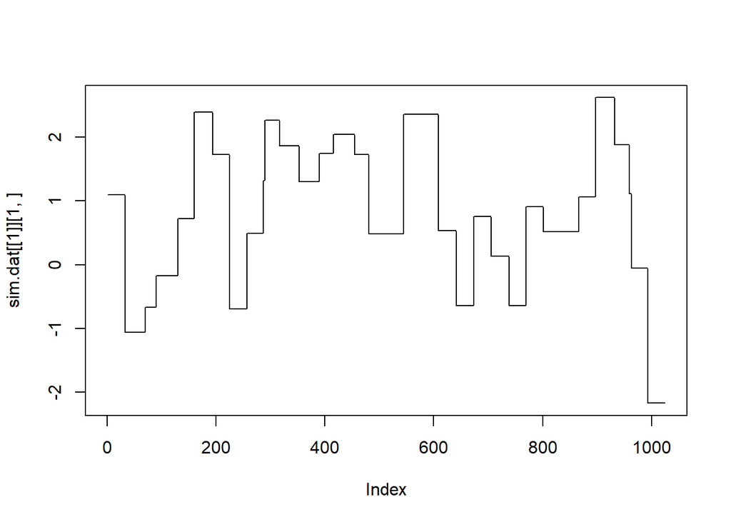

```r
# Plot
plot(sim.dat[[1]][1,], type="l")# First obs, already segmented
```

## CNAnhwt: performs the non-decimated Haar wavelet transform

This function performs the non-decimated Haar wavelet transform of the input vector and extract the detail/scaling coefficients. Given a scale *m*, the NDHW transform produces detail and scaling coefficients for each genomic location in each patient. The detail coefficients extract localised differences of CNA while the scaling coefficients extract localised mean of CNA with the window (of moving average).

```r
#Perform non-decimated Haar wavelet transform and extract the detail coefficients
sim.nhwt.det = CNAnhwt(sim.dat[[1]][1,], coef="d")
#Perform non-decimated Haar wavelet transform and extract the scaling coefficients
sim.nhwt.sca = CNAnhwt(sim.dat[[1]][1,], coef="s")
```

## plot.CNAnhwt: plot non-decimated Haar wavelet transform coefficients

This function plots non decimated Haar wavelet transform (NHWT) coefficients. You can choose How you want the coefficients to be scaled. The options are: “global”” - one scale factor is chosen for the whole plot. The scale factor depends on the coefficient to be included on the plot that has the largest absolute value. The global option is useful when comparing coefficients that might appear anywhere in the plot; “by.level” - a scale factor is chosen for each resolution scale in the plot. The scale factor for a resolution scale depends on the coefficient in that scale that has the largest absolute value. The by.level option is useful when you wish to compare coefficients within a resolution scale.

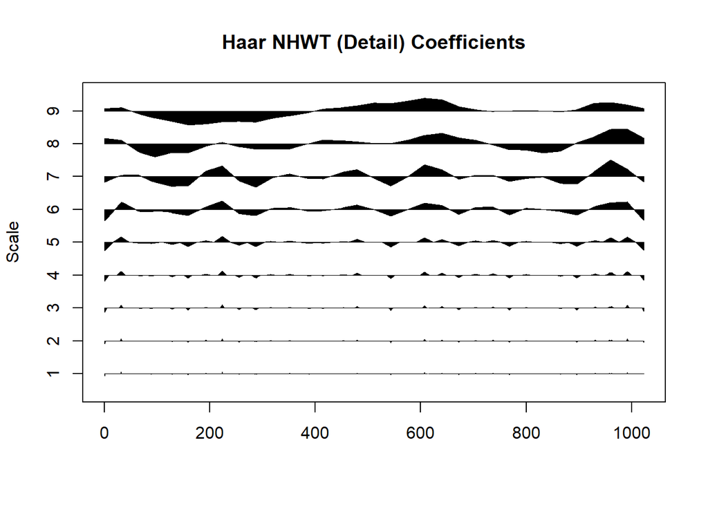

```r
#Plot NHWT detail coefficient
plot.CNAnhwt(sim.nhwt.det, coef="d", type="global")
```

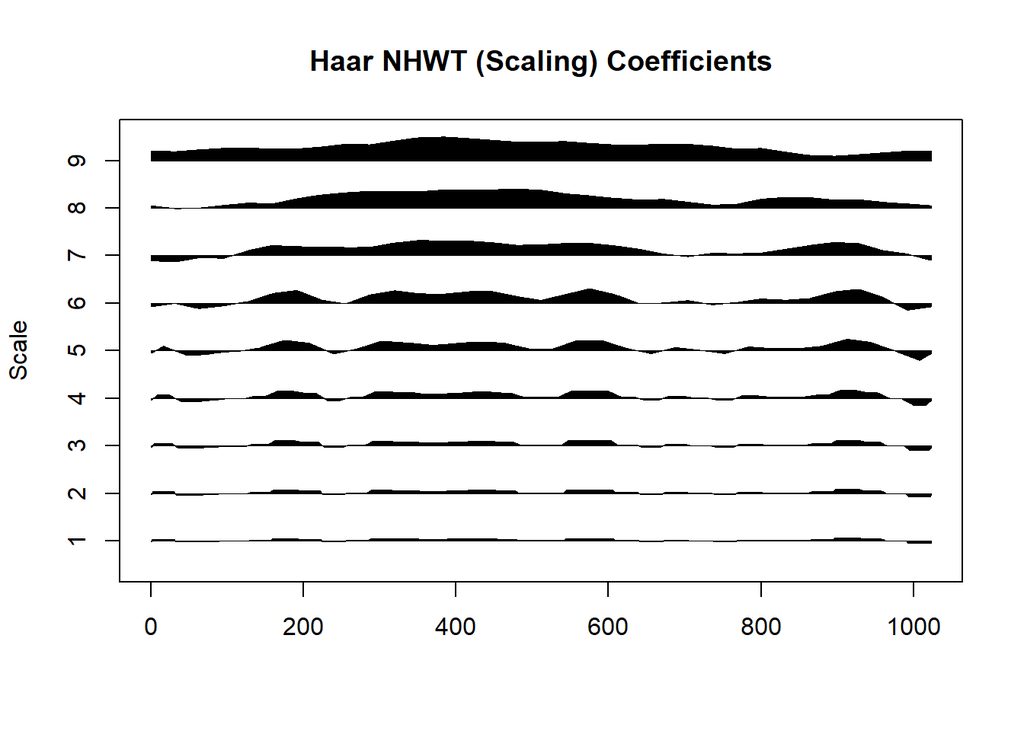

```r
#Plot NHWT scaling coefficient
plot.CNAnhwt(sim.nhwt.sca, coef="s", type="global")
```

## feat.extract: perform feature extraction

This function performs feature extraction using non-decimated Haar wavelet transformation, principal component analysis, and independent component analysis. The non-decimated Haar wavelet (NDHW) transformation is performed by the function `CNAnhwt`. The principal component analysis (PCA is performed using the function `prcomp` in the R base. The independent component analysis (ICA) is performed using `fastica` from the package `ica`. The segmentation (if called) is using circular binary segmentation (CBS) from the package `DNAcopy`.

```r
#feature extraction of simulated CNA data sim.dat using non-decimated Haar wavelet transformation (detail coefficient)
feat <- feat.extract(sim.dat[[1]], method="d", seg=FALSE)
length(feat) # 10 scales
```

```
## [1] 10
```

For NDHW transformation, the output is a list of detail or scaling coefficients at each scale. So, the length of the list is the number of scales. At each scale, the matrix of coefficients is of the same dimension of the original data. For PCA, a list of principal components in increasing number of components (cumulative). For ICA, a list of independent components in increasing number of components.

## rf.feat.extract: perform random forest on extracted features

This function performes random forest on extracted features, as output from the function `feat.extract`. The output is the out-of-bag error rate for each scale/component (columns).

```r
# Generate simulated CNA data
set.seed(10)
sim.dat <- sim.CNA() # one simulated data, 100 obs.
y <- factor(c(rep("Group1", 50), rep("Group2", 50)))

#feature extraction of simulated CNA data sim.dat using non-decimated Haar wavelet transformation (detail coefficient)
feat <- feat.extract(sim.dat[[1]], method="d", seg=FALSE)
length(feat) # 10 scales

#perform random forest  on the extracted detail coefficients
res <- rf.feat.extract(X=feat, y=y)
```

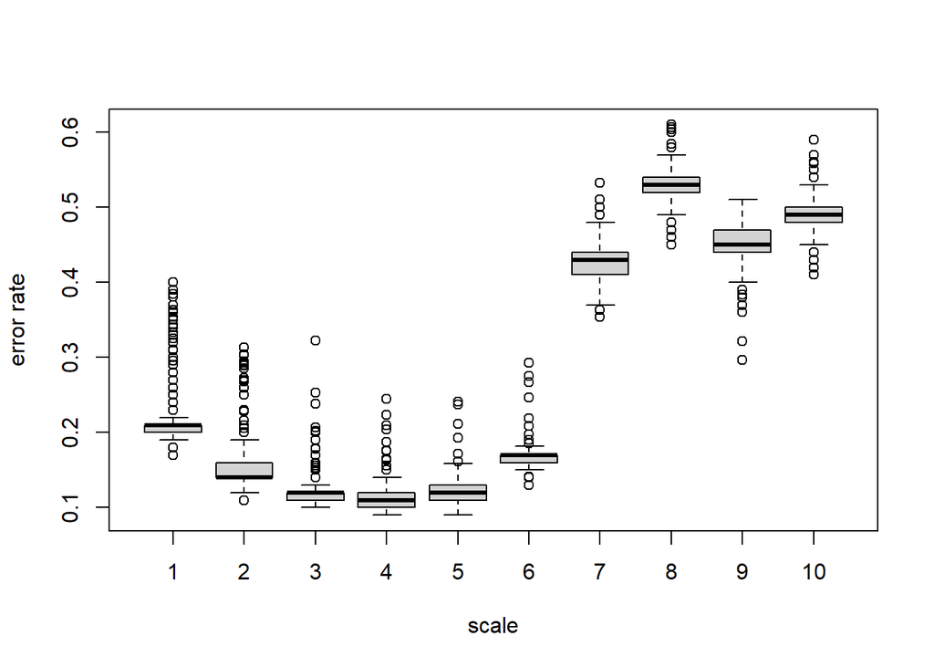

```r
#boxplot of the out-of-bag error rate for each scale
boxplot(res, ylab="error rate", xlab="scale", xaxt = "n")
axis(1, at = seq(1,10,1))
```